# Outbreak Investigation — Veronika’s Party, 26 February 2026

Retrospective Cohort Study

Field Epidemiology Team

2026-03-04

```r
library(tidyverse)
library(lubridate)
library(epitools)
library(incidence2)
library(scales)
```

# Background

On the evening of 26 February 2026, Veronika hosted a private dinner party. Within roughly 24 hours, multiple guests began reporting gastrointestinal symptoms. On learning of the cluster, we launched a retrospective cohort study to identify the source.

The goals of this investigation are to describe the outbreak in terms of person, place, and time; to identify the responsible food vehicle through analytical epidemiology; and to narrow down the likely pathogen based on the clinical and epidemiological profile.

The data were collected via a structured questionnaire sent to all known attendees. For each guest, we recorded demographic details, illness status, symptom onset and resolution times, and consumption of each of the 12 food items served at the party.

# Data Import and Cleaning

The raw dataset is a semicolon-delimited CSV in Latin-1 encoding, with German-format datetime strings (DD.MM.YYYY HH:MM). We rename the German food item columns to English and parse all date-time fields.

```r
raw <- read_delim(
  "data/Outbreak_data.csv",
  delim  = ";",
  locale = locale(encoding = "latin1")
)
```

```r
df <- raw %>%
  rename(
    smoked_salmon  = Räucherlachsrolle,
    tabouleh       = Taboule,
    tiramisu       = Tiramisu,
    hummus         = Hummus,
    panna_cotta    = `Panna Cotta`,
    spinach_quiche = Spinatquiche,
    bread          = Brot,
    tomato_mozz    = `Tomate Mozzarella`,
    raw_veggies    = Rohkost,
    herb_quark     = Kräuterquark,
    strawberries   = Erdbeeren,
    potato_salad   = Kartoffelsalat,
    travelled      = travelled_outside_ger_4_weeks,
    ill_prior      = ill_prior_party_4_weeks,
    still_ill      = stillill,
    blood_in_stool = bloodinstool,
    abdom_cramps   = abdominalcramps
  ) %>%
  mutate(
    arrival        = dmy_hm(arrival,   quiet = TRUE),
    symp_onset     = dmy_hm(symp_onset, quiet = TRUE),
    symp_stop      = dmy_hm(symp_stop,  quiet = TRUE),
    exposure_time  = dmy_hm(exposure_time, quiet = TRUE),
    sex            = factor(sex, levels = c("male", "female"))
  )

party_time <- dmy_hm("26.02.2026 19:00")

food_cols <- c("smoked_salmon", "tabouleh", "tiramisu", "hummus",
               "panna_cotta", "spinach_quiche", "bread", "tomato_mozz",
               "raw_veggies", "herb_quark", "strawberries", "potato_salad")
```

## Defining the Study Cohort

We restrict the analysis to those persons who actually attended the party (`attended = 1`). The `ill` field from the questionnaire is used directly as the case variable — all discrepancies identified in earlier data versions (e.g., Margarete Schubert originally miscoded as `ill = 0` despite reporting symptoms) have been corrected in the current dataset.

One minor data entry issue remains: Margarete Schubert’s `symp_stop` field is recorded as `28.02.202 20:00` (a missing digit in the year). We fix this in the cleaning step below.

Two derived variables are computed from the outset. **Incubation time** is the interval in hours from the fixed party start (26 Feb 19:00) to each case’s symptom onset. **Illness duration** is the interval from symptom onset to symptom resolution.

```r
cohort <- df %>%
  filter(attended == 1) %>%
  mutate(
    case = as.integer(ill == 1),
    # Fix Margarete Schubert's truncated symp_stop: "28.02.202 20:00" → proper datetime
    symp_stop = if_else(
      last == "Schubert" & first == "Margarete" & is.na(symp_stop),
      dmy_hm("28.02.2026 20:00", quiet = TRUE),
      symp_stop
    ),
    incubation_h = as.numeric(difftime(symp_onset, party_time, units = "hours")),
    duration_h   = as.numeric(difftime(symp_stop, symp_onset, units = "hours"))
  )
```

This gives us a cohort of **56** attendees, of whom **42** meet the case definition.

# Case Definition

> A **case** is defined as any person who attended Veronika’s party on 26 February 2026 and subsequently reported gastrointestinal illness (`ill = 1` on the questionnaire), characterised by vomiting, diarrhoea, and/or nausea.

```r
cohort %>%
  count(case) %>%
  mutate(pct = round(n / sum(n) * 100, 1)) %>%
  knitr::kable(col.names = c("Case (1=ill)", "n", "%"))
```

| Case (1=ill) | n | % |
| --- | --- | --- |
| 0 | 14 | 25 |
| 1 | 42 | 75 |

The overall **attack rate** is 75% — an exceptionally high proportion suggesting either a highly infectious agent, a heavily contaminated food vehicle that nearly everyone consumed, or both.

# Descriptive Epidemiology

## Who Was Affected?

We first describe the cases and non-cases by age and sex to see whether the outbreak shows any demographic pattern.

```r
cohort %>%
  group_by(case) %>%
  summarise(
    n      = n(),
    age_mean   = round(mean(age, na.rm = TRUE), 1),
    age_median = round(median(age, na.rm = TRUE), 1),
    age_range  = paste0(min(age, na.rm = TRUE), " – ", max(age, na.rm = TRUE)),
    .groups = "drop"
  ) %>%
  knitr::kable()
```

| case | n | age_mean | age_median | age_range |
| --- | --- | --- | --- | --- |
| 0 | 14 | 26.4 | 32.5 | 3 – 50 |
| 1 | 42 | 27.1 | 31.0 | 4 – 59 |

```r
cohort %>%
  group_by(sex) %>%
  summarise(n = n(), cases = sum(case), AR = paste0(round(cases/n*100,1), "%"),
            .groups = "drop") %>%
  knitr::kable(caption = "Attack rate by sex")
```

Attack rate by sex

| sex | n | cases | AR |
| --- | --- | --- | --- |
| male | 27 | 20 | 74.1% |
| female | 29 | 22 | 75.9% |

```r
cohort %>%
  mutate(age_grp = cut(age, breaks = c(0,10,18,30,45,Inf), right = FALSE,
                        labels = c("0-10","11-18","19-30","31-45","46+"))) %>%
  group_by(age_grp) %>%
  summarise(n = n(), cases = sum(case, na.rm = TRUE),
            AR = paste0(round(cases/n*100,1), "%"), .groups = "drop") %>%
  knitr::kable(caption = "Attack rate by age group")
```

Attack rate by age group

| age_grp | n | cases | AR |
| --- | --- | --- | --- |
| 0-10 | 16 | 11 | 68.8% |
| 11-18 | 4 | 4 | 100% |
| 19-30 | 3 | 3 | 100% |
| 31-45 | 29 | 21 | 72.4% |
| 46+ | 4 | 3 | 75% |

Both sexes and all age groups were affected at similar rates, which is typical of a common-source foodborne outbreak — the risk is determined by what you ate, not who you are.

# Epidemic Curve

The epidemic curve is the centrepiece of descriptive epidemiology. Its shape alone can distinguish a point-source outbreak (single sharp peak following a common exposure) from a propagated one (multiple successive waves reflecting person-to-person chains).

We use 3-hour bins and the EPIET convention of one stacked square per case. The x-axis has a two-level structure: 6-hour time marks (`00– 06– 12– 18–`) with full dates printed below, and vertical lines at midnight separating the days.

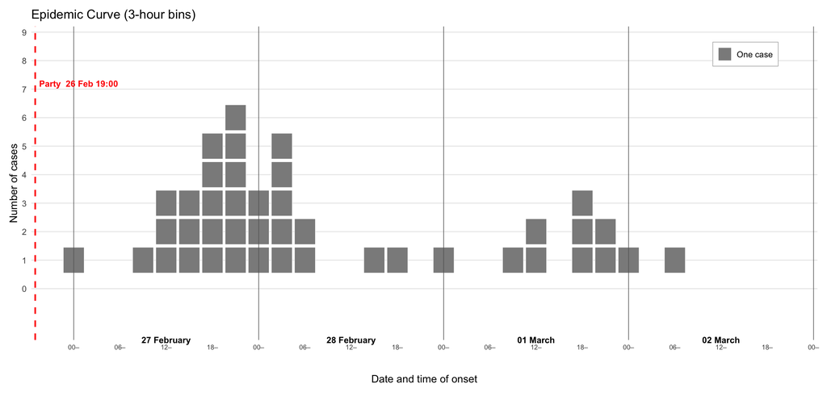

```r
onset_df <- cohort %>% filter(case == 1, !is.na(symp_onset))

bin_seconds <- 3 * 3600
onset_df <- onset_df %>%
  mutate(bin = as.POSIXct(floor(as.numeric(symp_onset) / bin_seconds) * bin_seconds,
                          origin = "1970-01-01", tz = "UTC")) %>%
  arrange(bin) %>%
  group_by(bin) %>%
  mutate(y = row_number()) %>%
  ungroup()

# Day boundaries for vertical separator lines at midnight
day_starts <- seq(
  from = as.POSIXct(floor(as.numeric(min(onset_df$bin)) / 86400) * 86400,
                    origin = "1970-01-01", tz = "UTC"),
  to   = max(onset_df$bin) + 86400,
  by   = "1 day"
)

# Date labels centred at midday of each day
day_labels_df <- tibble(
  x     = day_starts[-length(day_starts)] + 43200,
  label = format(day_starts[-length(day_starts)], "%d %B")
)

# 6-hour tick positions (00– 06– 12– 18–)
hour_ticks  <- seq(from = day_starts[1], to = max(day_starts), by = "6 hours")
hour_labs   <- paste0(format(hour_ticks, "%H"), "\u2013")

y_max <- max(onset_df$y)

ggplot(onset_df, aes(x = bin, y = y)) +
  geom_tile(aes(fill = "case"), width = bin_seconds * 0.9, height = 0.9,
            colour = "white", show.legend = TRUE) +
  scale_fill_manual(values = c("case" = "grey55"), labels = c("One case")) +
  geom_vline(xintercept = as.numeric(day_starts),
             colour = "grey40", linewidth = 0.3) +
  geom_vline(xintercept = as.numeric(party_time),
             linetype = "dashed", colour = "red", linewidth = 0.8) +
  annotate("text", x = party_time, y = y_max + 1.2,
           label = "Party  26 Feb 19:00", colour = "red",
           size = 3.2, hjust = -0.05, fontface = "bold") +
  scale_x_datetime(
    breaks = hour_ticks,
    labels = hour_labs,
    expand = expansion(mult = c(0.005, 0.005))
  ) +
  annotate("text", x = day_labels_df$x, y = -1.8,
           label = day_labels_df$label,
           size = 3.2, fontface = "bold") +
  scale_y_continuous(
    breaks = seq(0, 20, 1),
    expand = expansion(add = c(0, 2))
  ) +
  coord_cartesian(clip = "off") +
  labs(title = "Epidemic Curve (3-hour bins)",
       x = "Date and time of onset",
       y = "Number of cases",
       fill = NULL) +
  theme_minimal(base_size = 11) +
  theme(
    axis.text.x        = element_text(size = 7),
    axis.title.x       = element_text(margin = margin(t = 25)),
    panel.grid.minor   = element_blank(),
    panel.grid.major.x = element_blank(),
    legend.position      = c(0.95, 0.95),
    legend.justification = c(1, 1),
    legend.background    = element_rect(fill = "white", colour = "grey70",
                                        linewidth = 0.3),
    legend.key.size      = unit(0.5, "cm"),
    plot.margin          = margin(10, 10, 30, 10)
  )
```

## Daily Epicurve and Peak Estimation (incidence2)

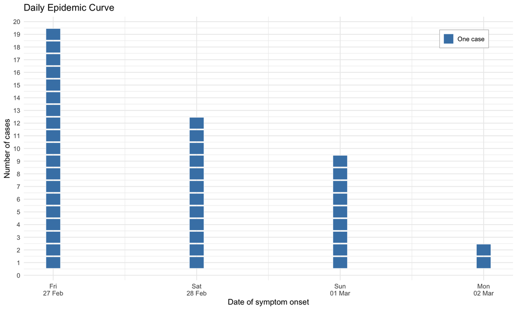

```r
cases_onset <- cohort %>%
  filter(case == 1, !is.na(symp_onset)) %>%
  mutate(onset_date = as.Date(symp_onset))

i_daily <- incidence(cases_onset, date_index = "onset_date",
                     date_names_to = "date")

# Build EPIET stacked-square plot
daily_df <- as.data.frame(i_daily)
squares <- daily_df %>%
  uncount(count) %>%
  group_by(date) %>%
  mutate(y = row_number()) %>%
  ungroup()

ggplot(squares, aes(x = date, y = y)) +
  geom_tile(aes(fill = "case"), width = 0.1, height = 0.9, colour = "white") +
  scale_fill_manual(values = c("case" = "steelblue"), labels = "One case") +
  scale_x_date(date_breaks = "1 day", date_labels = "%a\n%d %b") +
  scale_y_continuous(breaks = seq(0, 50, 1)) +
  labs(title = "Daily Epidemic Curve",
       x = "Date of symptom onset", y = "Number of cases", fill = NULL) +
  theme_minimal() +
  theme(axis.text.x = element_text(size = 9),
        legend.position = c(0.95, 0.95),
        legend.justification = c(1, 1),
        legend.background = element_rect(fill = "white", colour = "grey70",
                                         linewidth = 0.3),
        legend.key.size = unit(0.5, "cm"))
```

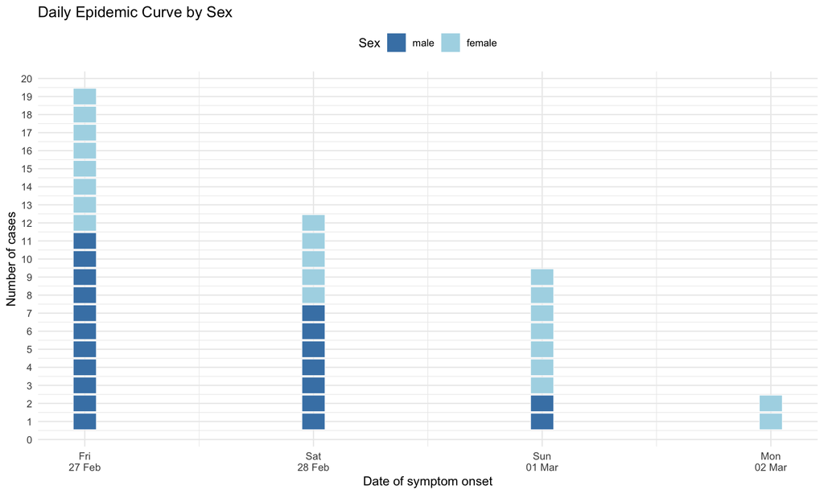

```r
i_sex <- incidence(cases_onset, date_index = "onset_date",
                   groups = "sex", date_names_to = "date")

sex_df <- as.data.frame(i_sex)
sex_squares <- sex_df %>%
  uncount(count) %>%
  arrange(date, sex) %>%
  group_by(date) %>%
  mutate(y = row_number()) %>%
  ungroup()

ggplot(sex_squares, aes(x = date, y = y, fill = sex)) +
  geom_tile(width = 0.1, height = 0.9, colour = "white") +
  scale_fill_manual(values = c("male" = "steelblue", "female" = "lightblue")) +
  scale_x_date(date_breaks = "1 day", date_labels = "%a\n%d %b") +
  scale_y_continuous(breaks = seq(0, 50, 1)) +
  labs(title = "Daily Epidemic Curve by Sex",
       x = "Date of symptom onset", y = "Number of cases", fill = "Sex") +
  theme_minimal() +
  theme(legend.position = "top",
        axis.text.x = element_text(size = 9))
```

### Identifying the Peak

The `keep_peaks()` function from `incidence2` returns the date(s) with the highest case count. For a confidence interval around the peak, `estimate_peak()` uses bootstrapping: it resamples the observed onset dates with replacement (100 times by default) and records which date is the peak in each resample, yielding a distribution of plausible peak dates.

```r
peak_row <- keep_peaks(i_daily)
cat("Observed peak day:", format(peak_row$date[1], "%A %d %B %Y"),
    "with", peak_row$count[1], "cases\n")
```

```
## Observed peak day: Friday 27 February 2026 with 19 cases
```

```r
set.seed(2026)
peak_est <- estimate_peak(i_daily, progress = FALSE) %>%
  select(-count_variable)
peak_est %>% knitr::kable(caption = "Bootstrap peak estimate (n = 100 resamples)")
```

Bootstrap peak estimate (n = 100 resamples)

| observed_peak | observed_count | bootstrap_peaks | lower_ci | median | upper_ci |
| --- | --- | --- | --- | --- | --- |
| 2026-02-27 | 19 | 20511, 20511, 20511, 20511, 20511, 20511, 20512, 20511, 20511, 20512, 20511, 20512, 20511, 20511, 20511, 20513, 20511, 20511, 20511, 20513, 20511, 20511, 20511, 20511, 20511, 20511, 20511, 20511, 2051… | 2026-02-27 | 2026-02-27 | 2026-02-28 |

## Cumulative Incidence

We compute the running total of cases by taking the cumulative sum of daily counts. For a point-source outbreak, this should form a characteristic S-shape: a slow start, a steep middle, and an early plateau.

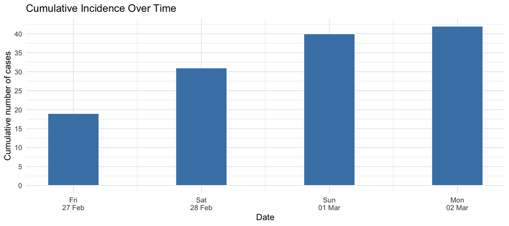

```r
# Compute cumulative incidence from the daily counts we already have
cum_df <- daily_df %>%
  arrange(date) %>%
  mutate(cumulative = cumsum(count))

ggplot(cum_df, aes(x = date, y = cumulative)) +
  geom_col(fill = "steelblue", width = 0.4, colour = "white") +
  scale_x_date(date_breaks = "1 day", date_labels = "%a\n%d %b") +
  scale_y_continuous(breaks = seq(0, 50, 5)) +
  labs(title = "Cumulative Incidence Over Time",
       x = "Date", y = "Cumulative number of cases") +
  theme_minimal() +
  theme(axis.text.x = element_text(size = 9))
```

# Incubation Period

The incubation period — the interval between exposure and symptom onset — is one of the most informative clues for identifying the pathogen. We calculate it as:

$$\text{Incubation (hours)} =
t_{\text{onset}} - t_{\text{party}}$$

where $t_{\text{party}}$ = 26 February 2026 at 19:00 (the start of food service). This treats all guests as having a common exposure time, which is reasonable since the party was a single evening event.

```r
inc <- cohort %>% filter(case == 1, !is.na(incubation_h))

inc_stats <- inc %>%
  summarise(
    n      = n(),
    mean   = round(mean(incubation_h), 1),
    median = round(median(incubation_h), 1),
    IQR    = paste0(round(quantile(incubation_h, .25), 1), " – ",
                    round(quantile(incubation_h, .75), 1)),
    range  = paste0(round(min(incubation_h), 1), " – ",
                    round(max(incubation_h), 1))
  )

inc_stats %>% knitr::kable(caption = "Incubation period (hours from party at 19:00)")
```

Incubation period (hours from party at 19:00)

| n | mean | median | IQR | range |
| --- | --- | --- | --- | --- |
| 42 | 38.6 | 29.6 | 25 – 53.2 | 5 – 83 |

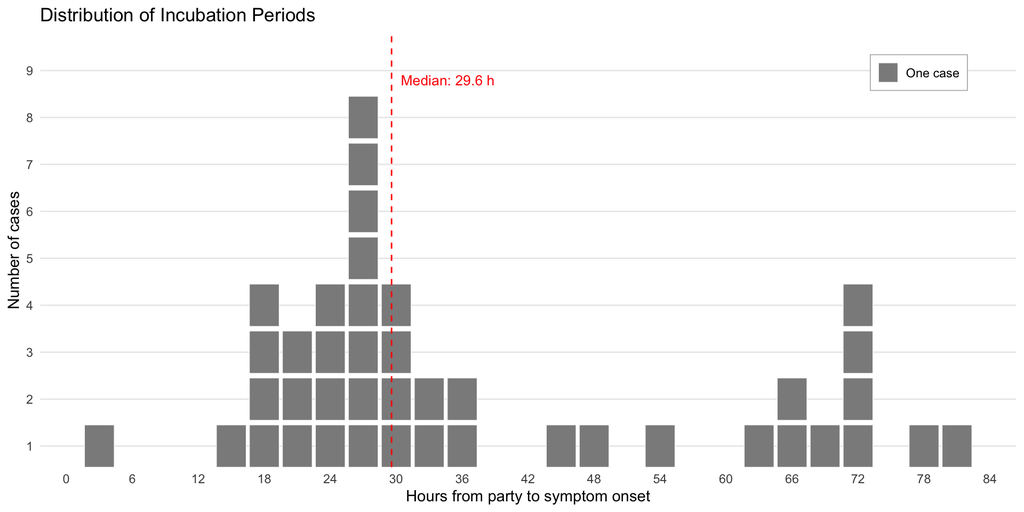

```r
inc_binned <- inc %>%
  mutate(bin = floor(incubation_h / 3) * 3) %>%
  arrange(bin) %>%
  group_by(bin) %>%
  mutate(y = row_number()) %>%
  ungroup()

ggplot(inc_binned, aes(x = bin, y = y)) +
  geom_tile(aes(fill = "case"), width = 2.7, height = 0.9, colour = "white",
            show.legend = TRUE) +
  scale_fill_manual(values = c("case" = "grey55"), labels = c("One case")) +
  geom_vline(xintercept = median(inc$incubation_h),
             linetype = "dashed", colour = "red") +
  annotate("text", x = median(inc$incubation_h), y = max(inc_binned$y) + 0.8,
           label = paste0("Median: ", round(median(inc$incubation_h), 1), " h"),
           hjust = -0.1, colour = "red", size = 3.5) +
  scale_x_continuous(breaks = seq(0, 84, 6)) +
  scale_y_continuous(breaks = seq(0, 20, 1), expand = expansion(add = c(0, 1))) +
  labs(title = "Distribution of Incubation Periods",
       x = "Hours from party to symptom onset", y = "Number of cases",
       fill = NULL) +
  theme_minimal(base_size = 11) +
  theme(panel.grid.minor = element_blank(), panel.grid.major.x = element_blank(),
        legend.position      = c(0.95, 0.95),
        legend.justification = c(1, 1),
        legend.background    = element_rect(fill = "white", colour = "grey70",
                                            linewidth = 0.3),
        legend.key.size      = unit(0.5, "cm"))
```

# Symptom Profile

The combination and relative frequency of symptoms helps narrow down the pathogen. Predominant vomiting points towards norovirus or *S. aureus* toxin, while diarrhoea-dominant illness with fever suggests *Salmonella* or *Campylobacter*.

```r
symp_cols <- c("nausea", "vomiting", "diarrhoea", "abdom_cramps",
               "headache", "fever", "blood_in_stool")

cases_df <- cohort %>% filter(case == 1)

symp_tbl <- tibble(
  symptom = symp_cols,
  n       = map_int(symp_cols, ~ sum(cases_df[[.x]] == 1, na.rm = TRUE)),
  pct     = round(n / nrow(cases_df) * 100, 1)
) %>%
  arrange(desc(pct))

symp_tbl %>% knitr::kable(caption = "Symptoms among cases")
```

Symptoms among cases

| symptom | n | pct |
| --- | --- | --- |
| vomiting | 42 | 100.0 |
| nausea | 41 | 97.6 |
| diarrhoea | 39 | 92.9 |
| abdom_cramps | 37 | 88.1 |
| headache | 29 | 69.0 |
| fever | 18 | 42.9 |
| blood_in_stool | 0 | 0.0 |

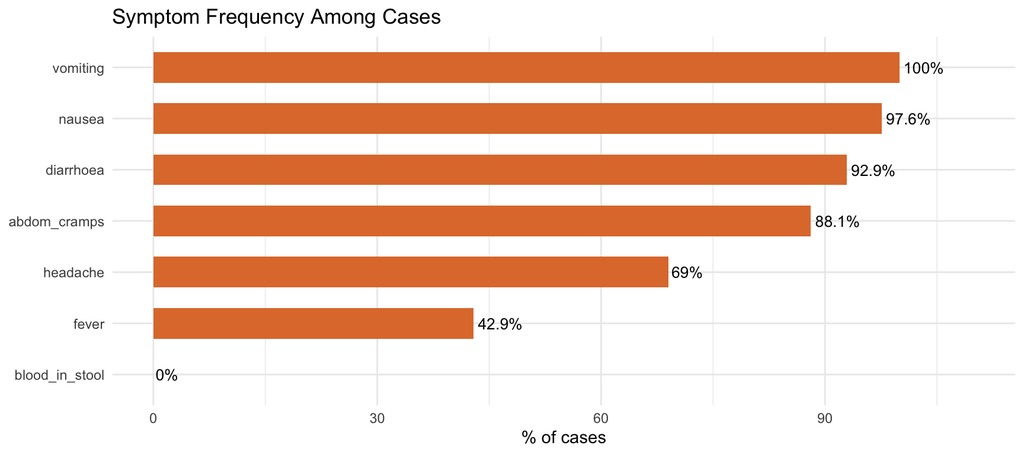

```r
symp_tbl %>%
  mutate(symptom = fct_reorder(symptom, pct)) %>%
  ggplot(aes(symptom, pct)) +
  geom_col(fill = "#E07B39", width = 0.6) +
  geom_text(aes(label = paste0(pct, "%")), hjust = -0.1, size = 3.5) +
  coord_flip() +
  scale_y_continuous(limits = c(0, 110)) +
  labs(title = "Symptom Frequency Among Cases",
       x = NULL, y = "% of cases") +
  theme_minimal()
```

Vomiting is universal (100%), nausea near-universal (98%), diarrhoea very common (93%), and there is zero bloody stool. Fever is present in about 43% of cases. This vomiting- predominant profile with no bloody stool strongly favours a viral or toxin-mediated aetiology over invasive bacterial pathogens.

## Illness Duration

Among cases where both onset and resolution times are available, illness duration is:

$$\text{Duration (hours)} =
t_{\text{stop}} - t_{\text{onset}}$$

```r
dur_df <- cohort %>%
  filter(case == 1, !is.na(duration_h), duration_h > 0)

dur_df %>%
  summarise(
    n = n(), mean = round(mean(duration_h), 1),
    median = round(median(duration_h), 1),
    IQR = paste0(round(quantile(duration_h, .25), 1), " – ",
                 round(quantile(duration_h, .75), 1)),
    range = paste0(round(min(duration_h), 1), " – ", round(max(duration_h), 1))
  ) %>%
  knitr::kable(caption = "Duration of illness (hours)")
```

Duration of illness (hours)

| n | mean | median | IQR | range |
| --- | --- | --- | --- | --- |
| 36 | 39.9 | 38.5 | 34.8 – 45 | 16 – 79 |

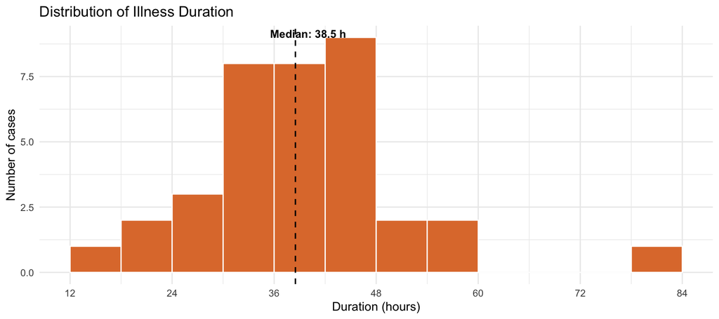

```r
ggplot(dur_df, aes(x = duration_h)) +
  geom_histogram(binwidth = 6, fill = "#E07B39", colour = "white", boundary = 0) +
  geom_vline(xintercept = median(dur_df$duration_h),
             linetype = "dashed", colour = "black", linewidth = 0.6) +
  annotate("text",
           x = median(dur_df$duration_h) + 1.5,
           y = Inf, vjust = 1.5,
           label = paste0("Median: ", round(median(dur_df$duration_h), 1), " h"),
           size = 3.5, fontface = "bold") +
  scale_x_continuous(breaks = seq(0, 120, 12)) +
  labs(title = "Distribution of Illness Duration",
       x = "Duration (hours)", y = "Number of cases") +
  theme_minimal()
```

The timeline below shows each case’s illness window from onset to recovery, ordered by when they first fell ill.

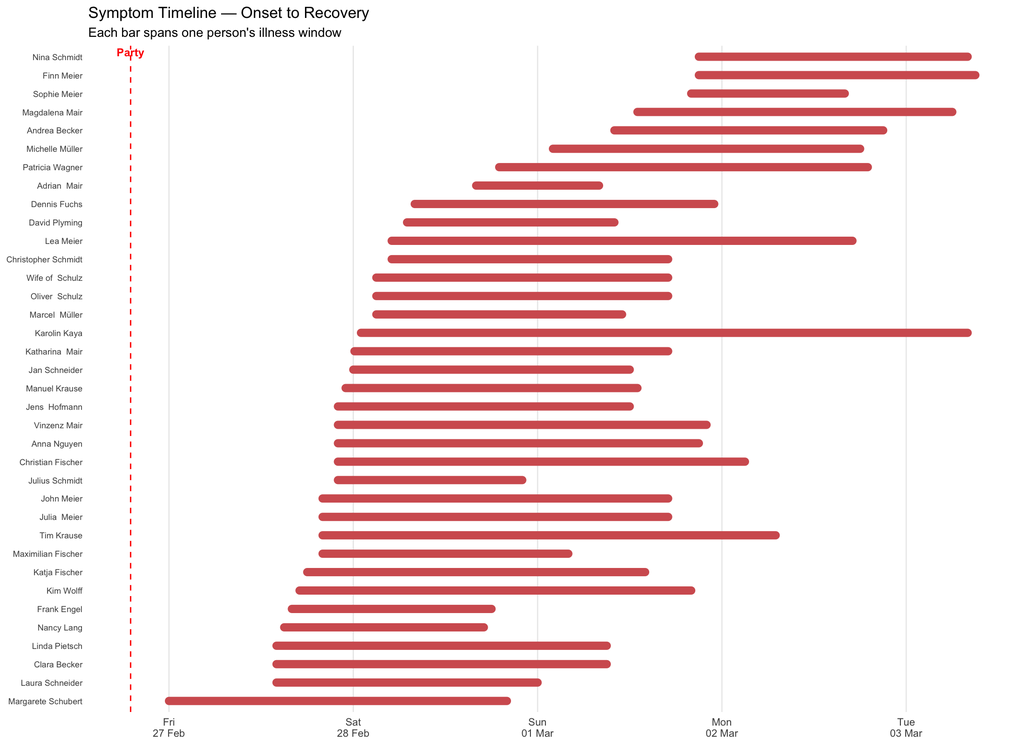

```r
timeline_df <- cohort %>%
  filter(case == 1, !is.na(symp_onset), !is.na(symp_stop)) %>%
  arrange(symp_onset) %>%
  mutate(person = paste0(first, " ", last),
         person = fct_inorder(person))

ggplot(timeline_df) +
  geom_segment(aes(x = symp_onset, xend = symp_stop,
                   y = person, yend = person),
               colour = "#D35F5F", linewidth = 3, lineend = "round") +
  geom_vline(xintercept = as.numeric(party_time),
             linetype = "dashed", colour = "red", linewidth = 0.5) +
  annotate("text", x = party_time, y = Inf, vjust = 1.3,
           label = "Party", colour = "red", size = 3, fontface = "bold") +
  scale_x_datetime(
    date_breaks = "1 day",
    date_labels = "%a\n%d %b",
    minor_breaks = NULL
  ) +
  labs(title = "Symptom Timeline — Onset to Recovery",
       subtitle = "Each bar spans one person's illness window",
       x = NULL, y = NULL) +
  theme_minimal(base_size = 10) +
  theme(axis.text.y        = element_text(size = 6.5),
        axis.text.x        = element_text(size = 8),
        panel.grid.major.y = element_blank())
```

Still ill at time of interview: **6** persons.

The self-limiting nature (median ~38 hours) is consistent with viral gastroenteritis. Bacterial toxin illness (*S. aureus*) resolves faster (< 24 h), while invasive infections (*Salmonella*) often last longer with more prominent fever.

# Food-Specific Attack Rates

This is the analytical heart of the investigation. For each of the 12 foods served, we construct a standard 2×2 table. The cells represent:

|  | Ill (case=1) | Well (case=0) |
| --- | --- | --- |
| **Ate the food** (exposed) | a | b |
| **Did not eat** (unexposed) | c | d |

From this we compute three key measures:

- **Attack rate among exposed** (AR<sub>exp</sub>) = a / (a + b)
- **Attack rate among unexposed** (AR<sub>unexp</sub>) = c / (c + d)
- **Risk ratio** (RR) = AR<sub>exp</sub> / AR<sub>unexp</sub>

A risk ratio significantly greater than 1.0 — with a confidence interval that does not include 1.0 and a Fisher’s exact p-value below 0.05 — indicates a statistically significant association between that food and illness.

We compute these using `epitab()` from the `epitools` package, which produces Wald 95% confidence intervals and Fisher’s exact p-values.

```r
food_ar <- map_dfr(food_cols, function(f) {

  tmp <- cohort %>%
    filter(!is.na(.data[[f]]), !is.na(case))

  a <- sum(tmp[[f]] == 0 & tmp$case == 0)   # unexposed, well
  b <- sum(tmp[[f]] == 0 & tmp$case == 1)   # unexposed, ill
  c <- sum(tmp[[f]] == 1 & tmp$case == 0)   # exposed, well
  d <- sum(tmp[[f]] == 1 & tmp$case == 1)   # exposed, ill

  mat <- matrix(c(a, b, c, d), nrow = 2, byrow = TRUE,
                dimnames = list(c("Unexposed", "Exposed"), c("Well", "Ill")))

  n_unexp <- a + b
  n_exp   <- c + d

  res <- tryCatch(
    epitab(mat, method = "riskratio", rev = "neither",
           pvalue = "fisher.exact", verbose = TRUE),
    error = function(e) NULL
  )

  if (is.null(res)) {
    return(tibble(food = f,
                  ill_exp = d, well_exp = c, n_exp = n_exp,
                  AR_exp = round(d / n_exp * 100, 1),
                  ill_unexp = b, well_unexp = a, n_unexp = n_unexp,
                  AR_unexp = round(b / n_unexp * 100, 1),
                  RR = NA, lower = NA, upper = NA, p = NA))
  }

  tibble(
    food      = f,
    ill_exp   = d,
    well_exp  = c,
    n_exp     = n_exp,
    AR_exp    = round(d / n_exp * 100, 1),
    ill_unexp = b,
    well_unexp = a,
    n_unexp   = n_unexp,
    AR_unexp  = round(b / n_unexp * 100, 1),
    RR        = round(res$tab["Exposed", "riskratio"], 2),
    lower     = round(res$tab["Exposed", "lower"], 2),
    upper     = round(res$tab["Exposed", "upper"], 2),
    p         = round(res$tab["Exposed", "p.value"], 4)
  )
})

food_ar %>%
  arrange(desc(RR)) %>%
  select(food, ill_exp, well_exp, n_exp, AR_exp,
         ill_unexp, well_unexp, n_unexp, AR_unexp,
         RR, lower, upper, p) %>%
  knitr::kable(
    caption = "Food-specific attack rates and risk ratios (Exposed | Unexposed)",
    col.names = c("Food", "Ill", "Well", "Total", "AR%",
                  "Ill", "Well", "Total", "AR%",
                  "RR", "Lower", "Upper", "p")
  )
```

Food-specific attack rates and risk ratios (Exposed | Unexposed)

| Food | Ill | Well | Total | AR% | Ill | Well | Total | AR% | RR | Lower | Upper | p |
| --- | --- | --- | --- | --- | --- | --- | --- | --- | --- | --- | --- | --- |
| tiramisu | 34 | 1 | 35 | 97.1 | 8 | 13 | 21 | 38.1 | 2.55 | 1.47 | 4.41 | 0.0000 |
| strawberries | 28 | 2 | 30 | 93.3 | 14 | 12 | 26 | 53.8 | 1.73 | 1.20 | 2.51 | 0.0013 |
| herb_quark | 30 | 4 | 34 | 88.2 | 12 | 10 | 22 | 54.5 | 1.62 | 1.08 | 2.41 | 0.0097 |
| spinach_quiche | 28 | 6 | 34 | 82.4 | 14 | 8 | 22 | 63.6 | 1.29 | 0.91 | 1.84 | 0.1295 |
| tomato_mozz | 21 | 4 | 25 | 84.0 | 21 | 10 | 31 | 67.7 | 1.24 | 0.92 | 1.67 | 0.2198 |
| smoked_salmon | 31 | 8 | 39 | 79.5 | 11 | 6 | 17 | 64.7 | 1.23 | 0.84 | 1.81 | 0.3171 |
| raw_veggies | 17 | 4 | 21 | 81.0 | 25 | 10 | 35 | 71.4 | 1.13 | 0.84 | 1.52 | 0.5325 |
| potato_salad | 27 | 8 | 35 | 77.1 | 15 | 6 | 21 | 71.4 | 1.08 | 0.78 | 1.49 | 0.7525 |
| tabouleh | 17 | 6 | 23 | 73.9 | 25 | 8 | 33 | 75.8 | 0.98 | 0.72 | 1.33 | 1.0000 |
| hummus | 17 | 6 | 23 | 73.9 | 25 | 8 | 33 | 75.8 | 0.98 | 0.72 | 1.33 | 1.0000 |
| bread | 17 | 7 | 24 | 70.8 | 25 | 7 | 32 | 78.1 | 0.91 | 0.66 | 1.24 | 0.5507 |
| panna_cotta | 12 | 6 | 18 | 66.7 | 30 | 8 | 38 | 78.9 | 0.84 | 0.59 | 1.22 | 0.3410 |

*Left block = Exposed (ate the food). Right block = Unexposed (did not eat).*

**Tiramisu** stands out dramatically. The table shows that nearly all those who ate it became ill, while the attack rate among those who did not eat it was far lower. The risk ratio — the highest of any food item — is statistically significant (p < 0.001), meaning a tiramisu eater was substantially more likely to become ill. Strawberries and herb quark also show significant associations, but with lower effect sizes — these may reflect confounding (see stratified analysis below).

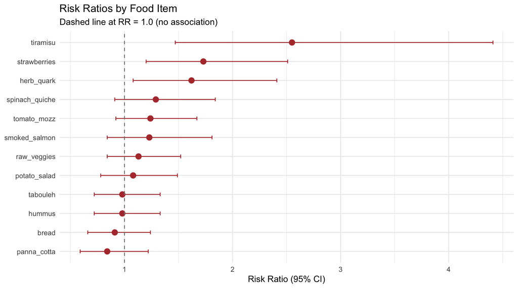

```r
food_ar %>%
  filter(!is.na(RR)) %>%
  mutate(food = fct_reorder(food, RR)) %>%
  ggplot(aes(x = food, y = RR)) +
  geom_point(size = 3, colour = "#B33A3A") +
  geom_errorbar(aes(ymin = lower, ymax = upper), width = 0.2, colour = "#B33A3A") +
  geom_hline(yintercept = 1, linetype = "dashed", colour = "grey50") +
  coord_flip() +
  labs(title = "Risk Ratios by Food Item",
       subtitle = "Dashed line at RR = 1.0 (no association)",
       x = NULL, y = "Risk Ratio (95% CI)") +
  theme_minimal()
```

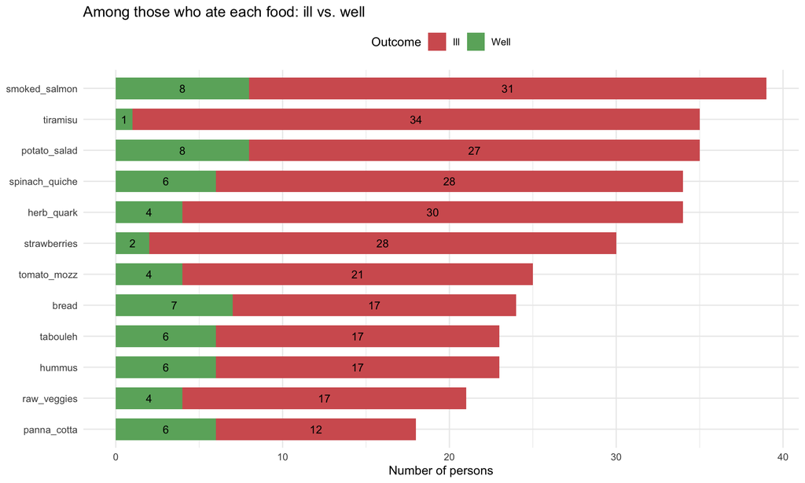

```r
food_long <- food_ar %>%
  select(food, ill_exp, well_exp) %>%
  pivot_longer(cols = c(ill_exp, well_exp),
               names_to = "outcome", values_to = "n") %>%
  mutate(outcome = ifelse(outcome == "ill_exp", "Ill", "Well"),
         food = fct_reorder(food, n, .fun = sum))

ggplot(food_long, aes(x = food, y = n, fill = outcome)) +
  geom_col(width = 0.7) +
  geom_text(aes(label = n), position = position_stack(vjust = 0.5), size = 3.5) +
  coord_flip() +
  scale_fill_manual(values = c("Ill" = "#D35F5F", "Well" = "#6BAF6B")) +
  labs(title = "Among those who ate each food: ill vs. well",
       x = NULL, y = "Number of persons", fill = "Outcome") +
  theme_minimal() +
  theme(legend.position = "top")
```

## Co-consumption: Tiramisu and Strawberries

The food-specific analysis flagged both tiramisu (highest RR) and strawberries as significantly associated with illness. Before concluding that two separate food items are independent risk factors, we need to check how strongly their consumption overlaps. If most people who ate strawberries also ate tiramisu, the strawberry signal may simply be piggybacking on the tiramisu effect (confounding by co-consumption).

We build a 2×2 co-consumption table crossing tiramisu and strawberry consumption, then colour-code each cell by the proportion who fell ill.

```r
# Cross-tabulate tiramisu × strawberry consumption and illness
co_df <- cohort %>%
  filter(!is.na(tiramisu), !is.na(strawberries)) %>%
  mutate(
    tiramisu_label    = ifelse(tiramisu == 1, "Ate tiramisu", "No tiramisu"),
    strawberry_label  = ifelse(strawberries == 1, "Ate strawberries", "No strawberries")
  ) %>%
  group_by(tiramisu_label, strawberry_label) %>%
  summarise(n = n(), cases = sum(case), AR = round(cases / n * 100, 1), .groups = "drop")

co_df %>% knitr::kable(caption = "Co-consumption of tiramisu and strawberries with attack rates")
```

Co-consumption of tiramisu and strawberries with attack rates

| tiramisu_label | strawberry_label | n | cases | AR |
| --- | --- | --- | --- | --- |
| Ate tiramisu | Ate strawberries | 22 | 22 | 100.0 |
| Ate tiramisu | No strawberries | 13 | 12 | 92.3 |
| No tiramisu | Ate strawberries | 8 | 6 | 75.0 |
| No tiramisu | No strawberries | 13 | 2 | 15.4 |

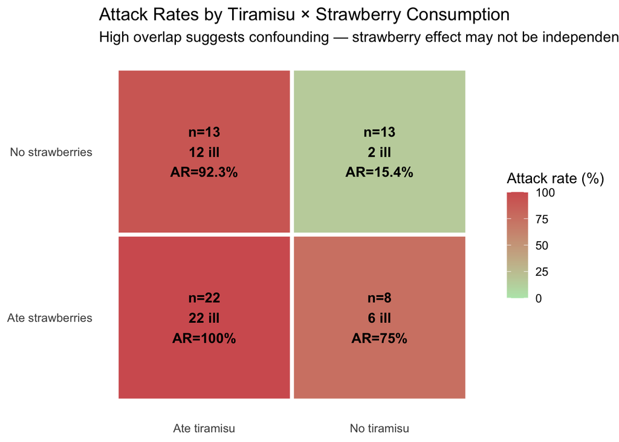

```r
# Mosaic-style heatmap: each cell sized by n, coloured by attack rate
ggplot(co_df, aes(x = tiramisu_label, y = strawberry_label)) +
  geom_tile(aes(fill = AR), colour = "white", linewidth = 1.5) +
  geom_text(aes(label = paste0("n=", n, "\n", cases, " ill\nAR=", AR, "%")),
            size = 4, fontface = "bold") +
  scale_fill_gradient(low = "#B8E6B8", high = "#D35F5F",
                      limits = c(0, 100), name = "Attack rate (%)") +
  labs(title = "Attack Rates by Tiramisu × Strawberry Consumption",
       subtitle = "High overlap suggests confounding — strawberry effect may not be independent",
       x = NULL, y = NULL) +
  theme_minimal(base_size = 12) +
  theme(panel.grid = element_blank(),
        legend.position = "right")
```

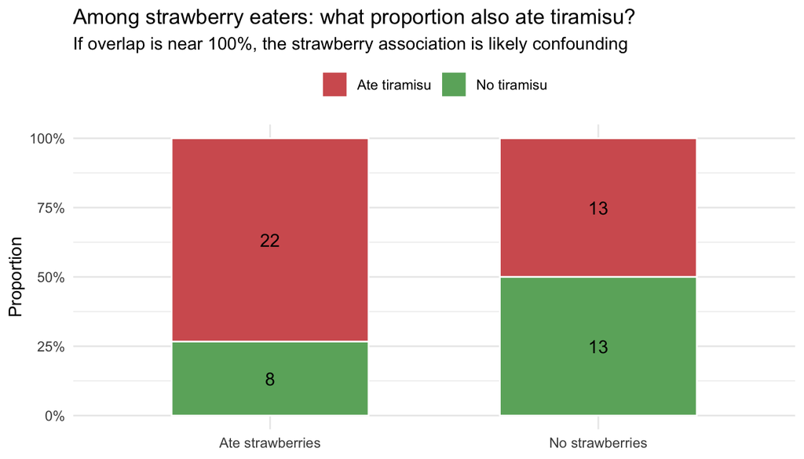

```r
# Stacked bar: among strawberry eaters vs non-eaters, what % also ate tiramisu?
venn_df <- cohort %>%
  filter(!is.na(tiramisu), !is.na(strawberries)) %>%
  mutate(
    strawberry_grp = ifelse(strawberries == 1, "Ate strawberries", "No strawberries"),
    tiramisu_grp   = ifelse(tiramisu == 1, "Ate tiramisu", "No tiramisu")
  ) %>%
  count(strawberry_grp, tiramisu_grp)

ggplot(venn_df, aes(x = strawberry_grp, y = n, fill = tiramisu_grp)) +
  geom_col(position = "fill", width = 0.6, colour = "white") +
  geom_text(aes(label = n), position = position_fill(vjust = 0.5), size = 4) +
  scale_fill_manual(values = c("Ate tiramisu" = "#D35F5F", "No tiramisu" = "#6BAF6B")) +
  scale_y_continuous(labels = percent_format()) +
  labs(title = "Among strawberry eaters: what proportion also ate tiramisu?",
       subtitle = "If overlap is near 100%, the strawberry association is likely confounding",
       x = NULL, y = "Proportion", fill = NULL) +
  theme_minimal() +
  theme(legend.position = "top")
```

The heatmap and stacked bar together reveal how tightly the two foods are linked: if nearly all strawberry eaters also ate tiramisu, then the strawberry RR is an artefact of co-consumption rather than an independent risk factor.

# Dose–Response

If tiramisu is truly the vehicle, we would expect a dose–response relationship: the more food items consumed, the higher the chance of having also eaten tiramisu, and hence the higher the attack rate.

```r
cohort %>%
  mutate(n_foods = rowSums(across(all_of(food_cols), ~ . == 1), na.rm = TRUE)) %>%
  group_by(n_foods) %>%
  summarise(n = n(), cases = sum(case, na.rm = TRUE),
            AR = round(cases / n * 100, 1), .groups = "drop") %>%
  knitr::kable(caption = "Attack rate by number of food items consumed")
```

Attack rate by number of food items consumed

| n_foods | n | cases | AR |
| --- | --- | --- | --- |
| 0 | 1 | 0 | 0.0 |
| 3 | 2 | 0 | 0.0 |
| 4 | 9 | 4 | 44.4 |
| 5 | 13 | 10 | 76.9 |
| 6 | 7 | 6 | 85.7 |
| 7 | 10 | 9 | 90.0 |
| 8 | 7 | 6 | 85.7 |
| 9 | 5 | 5 | 100.0 |
| 10 | 1 | 1 | 100.0 |
| 11 | 1 | 1 | 100.0 |

# Stratified Analysis

If the RR for tiramisu remains elevated and significant within each stratum, the association is robust and not explained by the confounder.

```r
strat_rr <- function(data, exposure, stratum) {
  lvls <- sort(na.omit(unique(data[[stratum]])))
  map_dfr(lvls, function(s) {
    sub <- data %>% filter(.data[[stratum]] == s, !is.na(.data[[exposure]]), !is.na(case))
    a <- sum(sub[[exposure]] == 0 & sub$case == 0)
    b <- sum(sub[[exposure]] == 0 & sub$case == 1)
    cc <- sum(sub[[exposure]] == 1 & sub$case == 0)
    d <- sum(sub[[exposure]] == 1 & sub$case == 1)
    mat <- matrix(c(a, b, cc, d), nrow = 2, byrow = TRUE,
                  dimnames = list(c("Unexposed","Exposed"), c("Well","Ill")))
    tryCatch({
      r <- epitab(mat, method = "riskratio", pvalue = "fisher.exact", verbose = TRUE)
      tibble(stratum = paste0(stratum, " = ", s), n = sum(mat),
             RR = round(r$tab["Exposed","riskratio"], 2),
             CI = paste0(round(r$tab["Exposed","lower"],2), "–",
                         round(r$tab["Exposed","upper"],2)),
             p  = round(r$tab["Exposed","p.value"], 4))
    }, error = function(e) {
      tibble(stratum = paste0(stratum, " = ", s), n = sum(mat),
             RR = NA_real_, CI = NA_character_, p = NA_real_)
    })
  })
}
```

```r
strat_rr(cohort, "tiramisu", "potato_salad") %>%
  knitr::kable(caption = "RR for tiramisu stratified by potato salad consumption")
```

RR for tiramisu stratified by potato salad consumption

| stratum | n | RR | CI | p |
| --- | --- | --- | --- | --- |
| potato_salad = 0 | 21 | 3.0 | 1.19–7.56 | 0.0015 |
| potato_salad = 1 | 35 | 2.3 | 1.17–4.51 | 0.0008 |

```r
strat_rr(cohort, "tiramisu", "sex") %>%
  knitr::kable(caption = "RR for tiramisu stratified by sex")
```

RR for tiramisu stratified by sex

| stratum | n | RR | CI | p |
| --- | --- | --- | --- | --- |
| sex = male | 27 | 3.33 | 1.29–8.59 | 0.0001 |
| sex = female | 29 | 2.08 | 1.08–4.01 | 0.0055 |

The tiramisu risk ratio stays well above 1.0 in every stratum — the association is not explained by potato salad consumption or sex.

# Confounders and Alternative Explanations

Before concluding that the outbreak was caused by a food served at the party, we rule out other explanations: recent travel outside Germany (a possible imported infection) and self-reported illness in the 4 weeks prior.

```r
cohort %>%
  count(travelled, case) %>%
  pivot_wider(names_from = case, values_from = n, names_prefix = "case_") %>%
  knitr::kable(caption = "Travel history vs. illness")
```

Travel history vs. illness

| travelled | case_0 | case_1 |
| --- | --- | --- |
| 0 | 9 | 35 |
| 1 | 3 | 7 |
| NA | 2 | NA |

```r
cohort %>%
  count(ill_prior, case) %>%
  pivot_wider(names_from = case, values_from = n, names_prefix = "case_") %>%
  knitr::kable(caption = "Prior illness (4 weeks before party) vs. case status")
```

Prior illness (4 weeks before party) vs. case status

| ill_prior | case_0 | case_1 |
| --- | --- | --- |
| 0 | 12 | 29 |
| 1 | 2 | 13 |

Neither travel nor prior illness is associated with case status.

# Household Clustering

Many guests attended as families. We tabulate attack rates by household to check for clustering.

```r
hh <- cohort %>%
  group_by(household) %>%
  summarise(members = n(), cases = sum(case, na.rm = TRUE),
            AR = paste0(round(cases / members * 100, 0), "%"), .groups = "drop") %>%
  arrange(desc(members))

hh %>% knitr::kable(caption = "Attack rate by household")
```

Attack rate by household

| household | members | cases | AR |
| --- | --- | --- | --- |
| 1 | 6 | 6 | 100% |
| 4 | 4 | 3 | 75% |
| 21 | 4 | 4 | 100% |
| 2 | 3 | 3 | 100% |
| 5 | 3 | 3 | 100% |
| 10 | 3 | 3 | 100% |
| 16 | 3 | 0 | 0% |
| 17 | 3 | 3 | 100% |
| 25 | 3 | 1 | 33% |
| 3 | 2 | 2 | 100% |
| 8 | 2 | 2 | 100% |
| 9 | 2 | 0 | 0% |
| 13 | 2 | 1 | 50% |
| 15 | 2 | 1 | 50% |
| 23 | 2 | 1 | 50% |
| 27 | 2 | 2 | 100% |
| 28 | 2 | 2 | 100% |
| 6 | 1 | 1 | 100% |
| 12 | 1 | 1 | 100% |
| 26 | 1 | 0 | 0% |
| 29 | 1 | 0 | 0% |
| 30 | 1 | 0 | 0% |
| 33 | 1 | 1 | 100% |
| 34 | 1 | 1 | 100% |
| 35 | 1 | 1 | 100% |

# Secondary Attack Rate and Reproduction Number

## Why R<sub>0</sub> Does Not Apply Here

The **basic reproduction number** (R<sub>0</sub>) is defined as the average number of secondary cases caused by a single infectious individual in a completely susceptible population (Karch, *Dynamics of Infection*). It is composed of three factors:

$$R_0 = \beta \times D \times
N$$

where $\beta$ is the probability of effective transmission per contact per unit time, $D$ is the duration of infectiousness, and $N$ is the population size. The **net reproduction number** adjusts for partial immunity:

$$R_n = R_0 \times s$$

where $s$ is the proportion of the population still susceptible.

These quantities assume **person-to-person transmission chains** — a case infects contacts who become new cases, who in turn infect further contacts. In our foodborne point-source outbreak, the primary route is food → person: a contaminated vehicle infects many people at once. There is no chain of human-to-human transmission to count, so R<sub>0</sub> in its classical sense does not apply.

## What We Can Assess: Evidence of Secondary Transmission

Even in a foodborne outbreak, secondary person-to-person spread can follow, especially with highly transmissible agents like norovirus. The **secondary attack rate** (SAR), defined by Karch as:

$$\text{SAR} = \frac{d}{N}$$

where $d$ is the number of secondary cases and $N$ is the total number of exposed contacts of a primary case (e.g., within a household), would be the right tool to quantify onward spread.

However, in our data all household members attended the party together — they are **co-exposed primary cases**, not unexposed household contacts of an index case. We therefore cannot compute a classical SAR. What we *can* do is examine the timing of symptom onsets within households: if a late-onset case appears well beyond the expected incubation window of the primary exposure (say, >48 h), that could signal secondary person-to-person transmission within the household.

```r
hh_onsets <- cohort %>%
  filter(case == 1, !is.na(symp_onset)) %>%
  group_by(household) %>%
  filter(n() >= 2) %>%
  summarise(
    n_cases    = n(),
    earliest   = min(symp_onset),
    latest     = max(symp_onset),
    spread_h   = as.numeric(difftime(max(symp_onset), min(symp_onset), units = "hours")),
    .groups    = "drop"
  ) %>%
  arrange(desc(spread_h))

hh_onsets %>%
  mutate(earliest = format(earliest, "%d %b %H:%M"),
         latest   = format(latest, "%d %b %H:%M")) %>%
  knitr::kable(caption = "Onset spread within households (2+ cases)")
```

Onset spread within households (2+ cases)

| household | n_cases | earliest | latest | spread_h |
| --- | --- | --- | --- | --- |
| 1 | 6 | 27 Feb 20:00 | 02 Mar 06:00 | 58 |
| 4 | 3 | 27 Feb 22:00 | 01 Mar 21:00 | 47 |
| 2 | 3 | 28 Feb 03:00 | 02 Mar 01:00 | 46 |
| 8 | 2 | 27 Feb 14:00 | 01 Mar 10:00 | 44 |
| 17 | 3 | 28 Feb 01:00 | 01 Mar 20:00 | 43 |
| 10 | 3 | 27 Feb 20:00 | 01 Mar 13:00 | 41 |
| 21 | 4 | 27 Feb 22:00 | 01 Mar 13:00 | 39 |
| 3 | 2 | 27 Feb 14:00 | 28 Feb 00:00 | 10 |
| 5 | 3 | 27 Feb 18:00 | 27 Feb 22:00 | 4 |
| 28 | 2 | 27 Feb 11:00 | 27 Feb 15:00 | 4 |
| 27 | 2 | 28 Feb 03:00 | 28 Feb 03:00 | 0 |

```r
n_wide <- sum(hh_onsets$spread_h > 48, na.rm = TRUE)
```

To visualise this directly, we plot every case’s symptom onset on a timeline, colour-coded by household. If secondary transmission were occurring, we would expect to see cases from the same household (same colour) appearing in two distinct clusters — an early group (primary cases from the food exposure) and a delayed group (secondary cases infected person-to-person). If instead all colours are intermixed in a single wave, the pattern favours co-exposure with individual variation in incubation.

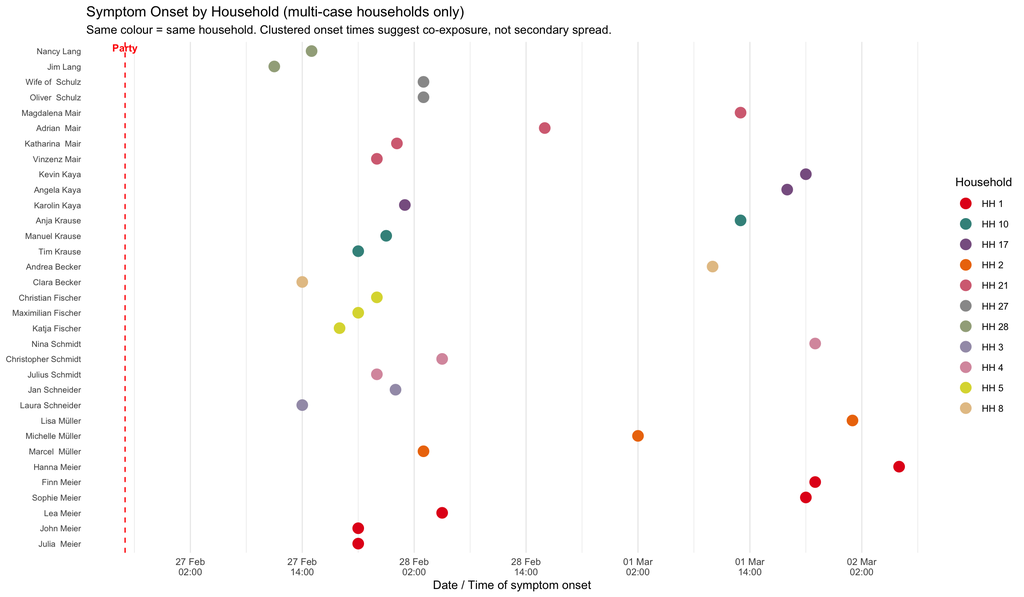

```r
# Keep only households with 2+ cases for meaningful clustering analysis
hh_cases <- cohort %>%
  filter(case == 1, !is.na(symp_onset)) %>%
  group_by(household) %>%
  filter(n() >= 2) %>%
  ungroup() %>%
  mutate(hh_label = paste0("HH ", household))

# Sort by onset within each household
hh_cases <- hh_cases %>%
  arrange(household, symp_onset) %>%
  mutate(person = paste0(first, " ", last),
         person = fct_inorder(person))

# Distinct colour palette for households
n_hh <- n_distinct(hh_cases$hh_label)
hh_colours <- setNames(
  colorRampPalette(c("#E41A1C","#377EB8","#4DAF4A","#984EA3","#FF7F00",
                     "#A65628","#F781BF","#999999","#66C2A5","#FC8D62",
                     "#8DA0CB","#E78AC3","#A6D854","#FFD92F","#E5C494"))(n_hh),
  sort(unique(hh_cases$hh_label))
)

ggplot(hh_cases, aes(x = symp_onset, y = person, colour = hh_label)) +
  geom_point(size = 4) +
  geom_vline(xintercept = as.numeric(party_time),
             linetype = "dashed", colour = "red", linewidth = 0.5) +
  annotate("text", x = party_time, y = Inf, vjust = 1.3,
           label = "Party", colour = "red", size = 3, fontface = "bold") +
  scale_x_datetime(date_breaks = "12 hours", date_labels = "%d %b\n%H:%M") +
  scale_colour_manual(values = hh_colours) +
  labs(title = "Symptom Onset by Household (multi-case households only)",
       subtitle = "Same colour = same household. Clustered onset times suggest co-exposure, not secondary spread.",
       x = "Date / Time of symptom onset", y = NULL, colour = "Household") +
  theme_minimal(base_size = 10) +
  theme(axis.text.y        = element_text(size = 7),
        axis.text.x        = element_text(size = 8),
        panel.grid.major.y = element_blank(),
        legend.position    = "right")
```

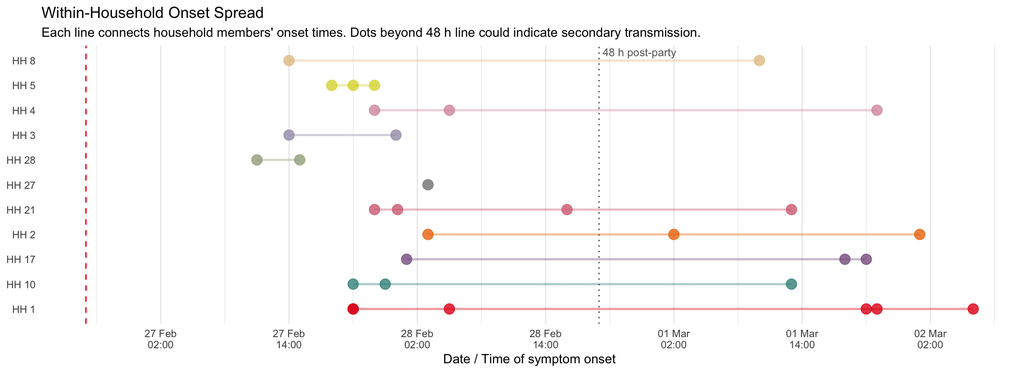

```r
# Strip plot: one row per household, dots at each member's onset
ggplot(hh_cases, aes(x = symp_onset, y = hh_label, colour = hh_label)) +
  geom_point(size = 3.5, alpha = 0.8) +
  geom_line(aes(group = hh_label), linewidth = 0.8, alpha = 0.4) +
  geom_vline(xintercept = as.numeric(party_time),
             linetype = "dashed", colour = "red", linewidth = 0.5) +
  geom_vline(xintercept = as.numeric(party_time + hours(48)),
             linetype = "dotted", colour = "grey40", linewidth = 0.5) +
  annotate("text", x = party_time + hours(48), y = Inf, vjust = 1.3,
           label = "48 h post-party", colour = "grey40", size = 3, hjust = -0.05) +
  scale_x_datetime(date_breaks = "12 hours", date_labels = "%d %b\n%H:%M") +
  scale_colour_manual(values = hh_colours, guide = "none") +
  labs(title = "Within-Household Onset Spread",
       subtitle = "Each line connects household members' onset times. Dots beyond 48 h line could indicate secondary transmission.",
       x = "Date / Time of symptom onset", y = NULL) +
  theme_minimal(base_size = 10) +
  theme(axis.text.x = element_text(size = 8),
        panel.grid.major.y = element_blank())
```

If norovirus is confirmed — a pathogen known for household secondary attack rates of 30–40% in published studies — follow-up investigation of household contacts who did *not* attend the party would be warranted to detect any onward spread.

# Pathogen Hypothesis

Combining the epidemiological and clinical findings:

```r
med_inc <- round(median(inc$incubation_h), 1)
overall_ar <- round(mean(cohort$case, na.rm = TRUE) * 100, 1)
```

| Feature | Observation |
| --- | --- |
| Incubation (median) | **29.6 hours** |
| Attack rate | 75% |
| Key symptoms | Vomiting (100%), nausea, diarrhoea, abdominal cramps |
| Bloody stool | 0% |
| Fever | ~43% |
| Duration (median) | ~38 hours, self-limiting |
| Epi curve | Point-source pattern |

**Differential diagnosis:**

- **Norovirus** — incubation 12–48 h, vomiting-predominant, very high attack rates, and notorious for secondary spread. Median incubation of ~30 h, 100% vomiting, no bloody stool, and self-limiting course all fit.
- **Staphylococcus aureus enterotoxin** — incubation 1–6 h. Excluded by the much longer incubation observed here.
- **Bacillus cereus (emetic type)** — incubation 1–6 h. Same exclusion.
- **Salmonella spp.** — incubation 6–72 h, typically more diarrhoea-dominant with higher fever. Possible but less consistent with the vomiting-predominant profile.
- **Clostridium perfringens** — incubation 6–24 h, primarily diarrhoea and cramps, vomiting less common. Median incubation here exceeds the typical range.

**Conclusion:** With a median incubation of **29.6 h**, universal vomiting, an attack rate of 75%, and a clear point-source curve, **norovirus** is the most probable agent. **Tiramisu** — the food item with the highest risk ratio — should be prioritised for virological testing. Stool samples from symptomatic cases should be collected for RT-PCR confirmation.